# Google play store Category Analysis

AJITH C

2025-07-21

## Problem

The majority of apps on the Google Play Store are Free, while Paid apps struggle with lower downloads. Developers often release Paid apps without understanding category-wise demand and user behavior. This imbalance leads to low visibility and financial losses for developers of Paid apps.

## Solution

- Analyze category-wise distribution of Free and Paid apps.
- Study average installs and ratings for both Free and Paid apps across categories.
- Identify categories where Paid apps still perform well despite being fewer in number.
- Provide recommendations on which categories are suitable for Paid app launches.

## ASK - Business Challenge

**Problem**

Imbalance between Free and Paid Apps

**Questions**

- Why is there a significant imbalance between Free and Paid apps in the Google Play Store?
- Why do developers often prefer to release Free apps rather than Paid apps?
- Why do Paid apps tend to have lower install counts compared to Free apps?
- Why do some Paid apps perform better in certain categories despite lower overall installs?
- Why is it important for developers to analyze category trends before deciding on app pricing models?

## PREPARE - Data collection and Sources

**Dataset Source:**  
[Kaggle — Google Play Store Apps Dataset](https://www.kaggle.com/datasets/lava18/google-play-store-apps)

**Key Attributes Used:**  
`App`, `Category`, `Rating`, `Reviews`, `Installs`, `Type`, `Price`, `Content Rating`

## PROCESS - Data cleaning and preparation

- Removed 483 duplicates.
- Removed Removed 1 row with invalid `Rating` 19.
- Handled missing values in `Current ver` column.
- Converted `Installs` to numerical format (removed commas and plus signs).
- Filtered apps with realistic install counts and valid categories.

[figure not shown]

Duplicates

[figure not shown]

Ratings

## ANALYZE - Data Exploration and Findings

### Category-wise Distribution of Free vs Paid Apps

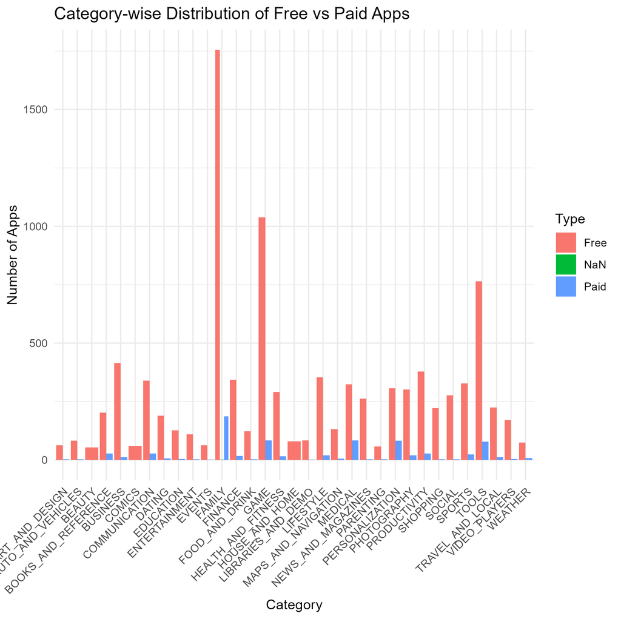

Graph

- **Observation**: Free apps dominate most categories.
- **Exception**: Some categories have a noticeable share of Paid apps.

### Average Installs: Free vs Paid Apps

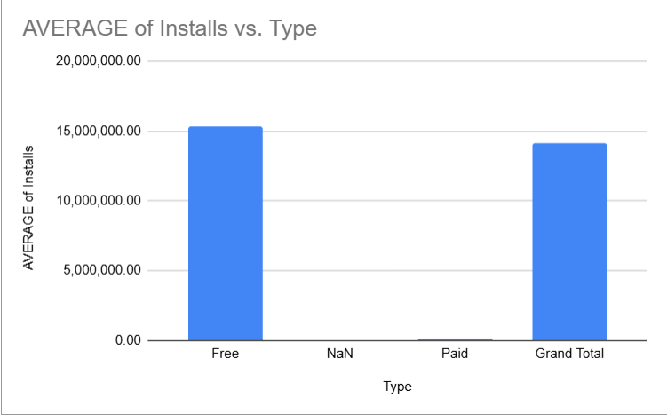

Average

### Average Ratings: Free vs Paid Apps

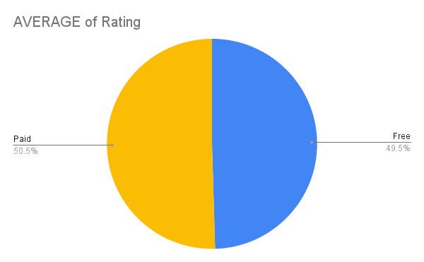

Average

**Observation**

- Paid apps tend to have slightly higher average ratings in selected categories.

## SHARE — Insights & Recommendations

[figure not shown]

Average

## ACT — Business Action Plan

- Focus on Free apps or Free + premium models to attract users in crowded categories.
- Use in-app purchases or ads for how you make money instead of upfront payment.
- Differentiate your app through unique features or better user experience.

**Overall Strategic Actions:**

- Conduct category analysis before deciding app pricing.
- Monitor category performance periodically to adapt business strategy.
- Use insights from data to make data-driven decisions for future app launches.

## Tools Used

- R
- Spreadsheets
- Tableau
- SQL

## Connect with me

Linkedin

[GitHub](https://github.com/Ajith-coder777)